# [OpenAI – ChatGPT and Codex – Coding with AI](https://fellows.fablearn.org/openai-chatgpt-and-codex-making-with-ai/)

Posted February 20, 2023 by Lars Beck Johannsen

*“In recent years, there has been an increasing interest in using artificial intelligence (AI) to improve the way we teach and learn. One promising application of AI in education is in coding, where tools like OpenAI Codex are changing the way students and teachers approach programming. OpenAI Codex is a state-of-the-art language model that can understand natural language and generate high-quality code in a variety of programming languages. In this blog post, we’ll explore the potential of OpenAI Codex as a powerful tool for coding in education, and how it can be used to enhance the learning experience for students and teachers alike.”*

This is how ChatGPT introduces Codex given the prompt “*write an introduction to a blogpost about using openAI codex for coding in education*”

It would be tempting to let it write the remaining blog but I will take it from here…

I have shown Codex to some of the kids that come in the lab and they have made different programs with it. At the time we didn´t save the code so I have only a picture from one of the games they made

[figure not shown]

I have since then learned that it’s fairly easy to save it as HTML and embed it on a website. I made this little program out of only 3 prompts:

https://sites.google.com/view/openaicodexexamples/escaperoom/next-level?authuser=2

The code could be a part of an escape room game (that was the idea). Click on the screen and type “Morpheus”, see what happens. I have written down the 3 prompts, and will try to feed it the same prompts in a couple of weeks to see the difference. You can see the prompts and the code generated here: https://sites.google.com/view/openaicodexexamples/escaperoom/next-level/prompt?authuser=2

–

Besides the turtle jumping game you can see in the picture (cookie clicker style), they made an “what’s the meaning of life game” a game where 42 is the answer. The AI itself chooses 42 as the answer (if you know it, you know).

–

They also tried to have it make horrible games like “killing babies game with fire”, which it had no ethic problems in programming. Midjourney on the hand would not let me prompt it to create a image of the game.

–

[figure not shown]

One thing that I have observed is that a lot of them seem to have fun with trying to mess with the AI. They told me about convincing the AI that 10+9 is 21, which is some meme, and when trained enough will accept that answer.  
Same kid wrote a paper on ChatGPT using ChatGPT to write it and got a 12 (highest grade possible i Denmark), he was transparent about using the tool.

–

I think AI´s like Codex, which is actually only a limited beta at the moment, is showing us a small peek into the future of programming. And actually watching the code being generated, reading it and making changes to the generated code, has given me insight into java that I have had little knowledge about prior to using codex.

–

In the “Enter the matrix” code I have linked to, I was changing some variables to have the green text background move a bit different than it suggested in the first place. I also changed the string for the correct password in the code. This was done by trial and error, but Codex is genrally good at naming functions and variables that makes sense.

–

In the lab I have a software developer, who tried out codex as well. He had a hard time making it work, he was talking to “programmy” to it. Setting up variables, naming them and doing all the stuff you would normally do. But it seems to work better when it has to be creative about what to do.

Another programmer I talked to uses Codex to start his projects now. According to him Codex gives him a 5 hours head start of the software he is writing. He also used ChatGPT to look at some piece of a code that was flawed and it solved the issue right away.

–

Codex is already changing the way professionals do their work, but it is just as potent in the hands of students. Just imagine when it gets good at 3D-modelling and microcontroller programming! One of my students succeeded in setting up an Arduino with code generated from ChatGPT. And with the AI functioning together with any API, that will be really interesting.

–

In April I will be having a workshop at the Danish Fablearn conference, that will use Codex or similar tools.

It is not just about using the tool for programming, AI also raises a lot of good questions and debates that I think is important to have with our students.

I also thought about creating an afterschool AI-club where we play around with the different engines and discuss pro´s and con´s of the tools.

In Denmark, the debate about ChatGPT as a tool for cheating with school assignments is ongoing. The debates range from banning the tools, restricting WiFi and so on. Probably not a good approach. One of the better suggestions is about changing the assignments and working together with AI instead: Analyzing the output that is generated. Checking the facts and statements that is generated. Letting the students prompt ChatGPT to writes about a topic that is well known to the student… will they agree with what is being generated? Or how about becoming a bias-detective?

How this technology will affect education in general will be interesting to see. I predict that it holds the potentiel to strengthening creativity, critical thinking and empowerment.

–

Lastly, I have been thinking about the role of humans and technology. I am not concerned or frightened by the technology, but I understand most of the concerns. Will programmers be unemployed in the future? Well, they will probably have a different task. I could imagine it being something like this image I have stitched together from three AI generated images made with Midjourney.

–

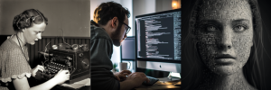

Almost 200 years ago Morse made the telegraph, and it required special knowledge to send and receive the code that enabled us to communicate. Today everyone can communicate over distance without that special skill. One could say that the morse code has evolved a better GUI – The telephone.

Coding has for a long time also been a special skill, and a lot of mysticism has been around coding. Now code can be generated by an AI, anyone can code if they can prompt their idea.

Imagine the AI being allowed, or being able, to write code that a human never would be able to think through or have the great overview in – which could give us software that is unimaginable today. Let us say that the telegrafist should morse the code that is running a zoom meeting, he would be hopelessly slow of course. Maybe that is how it would look for programmers in the future looking back at their colleagues in the 2020´s.

But where does that leave us as educators? Is it worth teaching them to code python for example? Is it more a question of learning to create prompts and think of algorithms?

# [Is ChatGPT a threat to education? For banking model of education, yes.](https://fellows.fablearn.org/is-chatgpt-a-threat-to-education/)

Posted January 16, 2023 by Charles Pimentel

Artificial Intelligence: Is ChatGPT a threat?

[figure not shown]

OpenAI’s ChatGPT is a newly developed Artificial Intelligence (AI) agent designed to perform high-level cognitive tasks and produce original text that is indistinguishable from the human-generated text. https://openai.com/blog/chatgpt.

It is essential to highlight that AI only reproduces the processes of our society, in activities for which it was trained, performing them with greater speed and, many times, greater accuracy than a human being. And this would not be different in the school context, revealing how outdated our educational system is.

For example, if a teacher proposes an activity in the classroom with the command “Make a dissertation about elections” the students will search for the theme on the internet and, rewriting the texts found and trying to connect them in a consistent way, they will present an original essay. ChatGPT performs the exact same process.

However, it is important to emphasize that writing a text does not mean learning and internalizing issues related to the topic, but only demonstrates the ability to carry out searches on Google and write respecting syntax and semantic rules. That’s what OpenAI’s application does… only faster.

Thus, when asking ChatGPT to talk about elections on two consecutive occasions, the platform presented two distinct and unpublished texts (which were classified as originals on platforms that identify plagiarism).

ChatGPT – Make a dissertation about elections – **Text 1** (first paragraph only)

> *Elections are a fundamental aspect of democratic societies, as they allow citizens to participate in the selection of their leaders and the direction of their government. The process of holding an election is both complex and vital, as it must be fair, transparent, and representative of the will of the electorate.*

ChatGPT – Make a dissertation about elections – **Text 2** (first paragraph only)

> *Elections are a process by which citizens of a country or members of a organization choose their leaders or representatives. This is typically done through a vote, in which eligible individuals cast their ballots for their preferred candidates or party. Elections can be held at different levels, such as national, state or local level, and are used to select leaders for government, political parties, and other organizations.*

Schools that value banking model education (a model based on the “deposit” of ideas and content in students) would give good grades to students who write texts like these, considering them prepared for society’s demands, as they “write well”. But education for the 21st century, which needs critical thinking, creativity and real problem solving, seeks to develop student skills and competencies that go beyond formal writing.

There are amazing, creative, critical, innovative and sensitive students who might not write as well as ChatGPT. In fact, writing skills and performing good searches in search engines are extremely important, but they are not the only resources that should be used to assess the student’s academic development.

AI and its applications need to be seen as allies for a constructionist education based on the ideas of Seymour Papert and also for a transformative education based on the critical and reflective pedagogical practice of Paulo Freire.

Mathematics, Languages and Humanities dialogue with each other when the school understands that the advancement of new technologies expands the opportunities for student-centered learning, promoting a multidisciplinary educational process, while seeking solutions for the real world.

Emerging technologies provide opportunities in the school context for an active and meaningful learning environment, provoking important reflections on what is expected from the 21st century school.

ChatGPT has other functions, in addition to creating unpublished texts, which can be checked at the aforementioned web address. However, this application of AI is fomenting an important discussion: *Where should Education for the New Millennium go*?

# [STEM Education: Purpose, Process and Scalability](https://fellows.fablearn.org/stem-purpose-process-scalability/)

Posted January 11, 2023 by Charles Pimentel

[figure not shown]

###### Science, Technology, Engineering & Mathematics

#### STEM Education finds consistent support in Maker-Based Learning through Design Thinking

#### “STEM Education is far more than a “convenient integration” of its four disciplines, rather it encompasses “real-world, problem-based learning” that links the disciplines “through cohesive and active teaching and learning approaches” ” (STEM Task Force Report, 2014)

STEM was initially proposed in the 90s in the United States, with the acronym SMET, as the integration of areas of knowledge aimed to promote an educational process with applications in the real world.

At the end of the first decade of the 21st century, the approach gained strength in the United States through the *Innovate to Educate Program*, proposed by the Barack Obama administration. The US president referred to this program as “America’s new Sputnik moment”, referring to the Soviet rocket launch in the 1950s, beating the Americans in the space race. The “Sputnik moment” led his country to invest in research and education, promoting a wave of innovation in the country, creating many jobs.

The multidisciplinary approach is also transdisciplinary, covering areas of knowledge that break with the four disciplines of the acronym, and open doors for rethinking the fragmented education model, in force for decades.

By promoting the development of skills related to critical thinking and problem-solving, STEM Education also makes students understand their place in society as protagonists of the world they live in. An important ally for STEM education is Maker-based Learning.

- **Maker-based Learning: the power of learning by doing**

Experiential education places the student at the center of their learning. Currently, schools and educational networks are investing in innovation spaces, with resources for rapid prototyping such as Laser Cutters, 3D Printers, Plotters, Milling Machines and equipment such as Dremel rotary tools, drills, screwdrivers and equipment generally used in workshops (hammers, handsaw, screwdriver). These spaces are named *Makerspaces*.

One of the inspirations for *Makerspaces* is the Digital Fabrication and rapid prototyping environment called FabLab, which originated in 2002 at MIT through the collaboration between the Grupo de Invenções de Base and the Center for Bits and Atoms (CBA) with the objective of bringing Digital Fabrication to common people (Blikstein & Krannich, 2013). These spaces enhance and streamline the production of artifacts, enabling projects that are closer to reality to be prototyped.

In this way, Maker-Based Learning teaches the learner how to deal with challenges and face an unexpected problem for which there is no pre-established explanation, acquiring skills necessary to participate in the construction of new skills (Gavassa, 2020). However, it is important to consider the integration of Maker Spaces into the school curriculum, accompanied by actions so that their use provides authentic and meaningful learning experiences (Fernandez et al., 2021).

- **Purpose, Process and Scalability**

> The triad **purpose, process and scalability** are important elements for STEM Education to be implemented in a local context, that is, in a classroom or school, and in a broader context, such as public and private education networks.

*I – Purpose – Case: Brazilian School Initiative “Math Maker”*

###### *Purpose (noum) – why you do something or why something exists (Cambrige Dictionary, 2023)*

It seems obvious, but having a **well-defined purpose** is very important for the successful implementation of initiatives related to STEM Education in schools and teaching networks.  
For example, it is important to define a *generative theme*, such as sustainability, environmental protection or renewable energy, which are important topics to be debated by students anywhere in the world, because how the next generation will deal with these issues will shape the future.

[figure not shown]

Botany STEM Project through chart reading

A case developed in a Brazilian high school is the **Math Maker Project**. The initiative was built with the purpose of introducing educational activities in basic education that encourage debates for the implementation of actions carried out by students that contribute to solutions for the Sustainable Development Goals (SDGs) during STEM classes.

> **Math Maker Project** – In order to explore Mathematics as a language in which students are empowered to put their ideas into practice through STEM projects, Mathematics Maker is an elective course created for high school students to be protagonists in their educational process, appropriating it if from Makerspace resources.

> *It’s a school subject based on Discovery Learning (DL) and the Project-Based Learning (PBL) methodology.*

> *The DL considers that activities where students initially explore concepts, asking themselves questions and formulating their own theory of a phenomenon, before receiving formal instruction, provide learning that goes beyond a specific subject (Schneider and Blikstein 2015).*

> *Learning occurs as a result of handling, structuring and transforming information, generating new knowledge. In learning mathematical concepts, from the development of projects, the student elaborates a conjecture, formulates hypotheses and makes discoveries using inductive or deductive processes, observations and extrapolation. The essential element in discovering new information is that the student must actively participate in formulating and obtaining knowledge (Prasad, 2011).*

> *In addition, the methodology that guides the Math Maker subject is Project-Based Learning. The PBL proposes the construction of knowledge through a long and continuous work of research, with the objective of answering a question, a challenge or a problem. From then on, students begin a process of exploration, establishing hypotheses and looking for resources to develop the project. It involves the practical application of the information obtained until reaching a final product or a satisfactory solution to the initial question. Learning assessment is done during the process and after the presentation of the final product.*

An important factor in the successful implementation of STEM education is the process. DL and PBL in Maker Math are conducted through the **Design Thinking Process**.

**II – Process – The power of Design Thinking**